# Machine Learning - Course Project

Francis Labrecque

3/28/2020

## Synopsis

The goal of this report is to propose a prediction model on how well people do a barbell lifts. To do so, they collected data from 6 participants while wearing accelerometers on their belt, forearm, arm, and a dumbell. They were asked to perform the barbell lifts correctly (“classe”=A) and incorrectly in 4 different ways (“classe”=c(B:E)).

## Loading packages

The following are all the different libraries needed to complete this report.

```r
set.seed(4678)
library(caret)
library(dplyr)
library(ggplot2)
library(gridExtra)
```

## Data loading and Preprocessing

The dataset can be found here http://web.archive.org/web/20161224072740/http:/groupware.les.inf.puc-rio.br/har#literature. Once downloaded to our working directory, we take a quick look at the data using a spreadsheet program and noticed that the data contains different types of missing values. In order to harmonize them, we set them to NA through the read.csv function.

```r
trainingDB <- read.csv("pml-training.csv", header = TRUE, na.strings=c("", "#DIV/0!", "NA"))
valid <- read.csv("pml-testing.csv", header = TRUE, na.strings=c("", "#DIV/0!", "NA"))
```

The data was already split into training and testing sets. We are setting the testing set as our validation set and we are splitting the training set into new training and testing sets.

Since predictive models do not deal well with missing values, we use the following function to have a look at the number of NA values for each variables (Because of its length, the results are not shown). we found that many variables are populated with 98%+ of missing values and we proceed with removing them.

```r
sapply(trainingDB, function(x)sum(is.na(x)))
trainingDB <- trainingDB %>% select_if(~ !any(is.na(.)))
valid <- valid %>% select_if(~ !any(is.na(.)))
```

```r
trainingDB <- trainingDB[,-c(1:7)]
valid <- valid[,c(1:7)]
```

We now create a testing set out of the training set:

```r
inTrain <- createDataPartition(y=trainingDB$classe, p=0.6, list = FALSE)
training <- trainingDB[inTrain,]
testing <- trainingDB[-inTrain,]
```

## Exploratory Data Analysis

Let’s explore the training dataset.

```r
dim(training)
## [1] 11776    53
summary(training)
##    roll_belt        pitch_belt          yaw_belt       total_accel_belt
##  Min.   :-28.90   Min.   :-54.9000   Min.   :-180.00   Min.   : 0.0
##  1st Qu.:  1.11   1st Qu.:  1.7300   1st Qu.: -88.20   1st Qu.: 3.0
##  Median :115.00   Median :  5.3000   Median : -11.65   Median :17.0
##  Mean   : 65.04   Mean   :  0.3558   Mean   : -10.68   Mean   :11.4
##  3rd Qu.:123.00   3rd Qu.: 15.5000   3rd Qu.:  13.30   3rd Qu.:18.0
##  Max.   :162.00   Max.   : 60.3000   Max.   : 179.00   Max.   :29.0
##   gyros_belt_x        gyros_belt_y       gyros_belt_z      accel_belt_x
##  Min.   :-1.040000   Min.   :-0.64000   Min.   :-1.3300   Min.   :-120.00
##  1st Qu.:-0.030000   1st Qu.: 0.00000   1st Qu.:-0.2000   1st Qu.: -21.00
##  Median : 0.030000   Median : 0.02000   Median :-0.1100   Median : -15.00
##  Mean   :-0.005448   Mean   : 0.03947   Mean   :-0.1319   Mean   :  -5.62
##  3rd Qu.: 0.110000   3rd Qu.: 0.11000   3rd Qu.:-0.0200   3rd Qu.:  -5.00
##  Max.   : 2.220000   Max.   : 0.56000   Max.   : 1.6200   Max.   :  83.00
##   accel_belt_y     accel_belt_z    magnet_belt_x    magnet_belt_y
##  Min.   :-69.00   Min.   :-275.0   Min.   :-52.00   Min.   :354.0
##  1st Qu.:  3.00   1st Qu.:-162.0   1st Qu.:  9.00   1st Qu.:581.0
##  Median : 37.00   Median :-153.0   Median : 34.00   Median :601.0
##  Mean   : 30.45   Mean   : -73.7   Mean   : 55.51   Mean   :593.4
##  3rd Qu.: 61.00   3rd Qu.:  27.0   3rd Qu.: 60.00   3rd Qu.:610.0
##  Max.   :164.00   Max.   : 105.0   Max.   :481.00   Max.   :669.0
##  magnet_belt_z       roll_arm         pitch_arm          yaw_arm
##  Min.   :-623.0   Min.   :-180.00   Min.   :-88.200   Min.   :-180.0000
##  1st Qu.:-375.0   1st Qu.: -32.20   1st Qu.:-25.200   1st Qu.: -43.2000
##  Median :-320.0   Median :   0.00   Median :  0.000   Median :   0.0000
##  Mean   :-345.9   Mean   :  17.79   Mean   : -4.109   Mean   :  -0.5675
##  3rd Qu.:-306.0   3rd Qu.:  77.00   3rd Qu.: 11.900   3rd Qu.:  46.4000
##  Max.   : 293.0   Max.   : 180.00   Max.   : 88.500   Max.   : 180.0000
##  total_accel_arm  gyros_arm_x        gyros_arm_y       gyros_arm_z
##  Min.   : 1.00   Min.   :-6.37000   Min.   :-3.4000   Min.   :-2.3300
##  1st Qu.:17.00   1st Qu.:-1.33000   1st Qu.:-0.7900   1st Qu.:-0.0800
##  Median :27.00   Median : 0.08000   Median :-0.2400   Median : 0.2300
##  Mean   :25.48   Mean   : 0.03579   Mean   :-0.2529   Mean   : 0.2681
##  3rd Qu.:33.00   3rd Qu.: 1.56000   3rd Qu.: 0.1600   3rd Qu.: 0.7200
##  Max.   :66.00   Max.   : 4.87000   Max.   : 2.8400   Max.   : 2.9900
##   accel_arm_x       accel_arm_y       accel_arm_z       magnet_arm_x
##  Min.   :-404.00   Min.   :-315.00   Min.   :-636.00   Min.   :-584.0
##  1st Qu.:-243.00   1st Qu.: -54.00   1st Qu.:-142.00   1st Qu.:-302.0
##  Median : -46.00   Median :  12.50   Median : -45.00   Median : 282.0
##  Mean   : -60.61   Mean   :  31.92   Mean   : -70.29   Mean   : 189.0
##  3rd Qu.:  84.00   3rd Qu.: 138.00   3rd Qu.:  24.00   3rd Qu.: 635.2
##  Max.   : 435.00   Max.   : 308.00   Max.   : 245.00   Max.   : 780.0
##   magnet_arm_y     magnet_arm_z    roll_dumbbell     pitch_dumbbell
##  Min.   :-392.0   Min.   :-597.0   Min.   :-153.71   Min.   :-149.59
##  1st Qu.:  -8.0   1st Qu.: 134.0   1st Qu.: -18.92   1st Qu.: -40.51
##  Median : 204.0   Median : 445.0   Median :  47.84   Median : -20.97
##  Mean   : 157.9   Mean   : 308.8   Mean   :  23.53   Mean   : -10.65
##  3rd Qu.: 323.0   3rd Qu.: 546.0   3rd Qu.:  67.37   3rd Qu.:  17.68
##  Max.   : 583.0   Max.   : 694.0   Max.   : 153.38   Max.   : 137.03
##   yaw_dumbbell      total_accel_dumbbell gyros_dumbbell_x    gyros_dumbbell_y
##  Min.   :-150.871   Min.   : 0.0         Min.   :-204.0000   Min.   :-2.07000
##  1st Qu.: -77.730   1st Qu.: 4.0         1st Qu.:  -0.0300   1st Qu.:-0.14000
##  Median :  -2.640   Median :10.0         Median :   0.1300   Median : 0.03000
##  Mean   :   1.646   Mean   :13.7         Mean   :   0.1557   Mean   : 0.04513
##  3rd Qu.:  80.431   3rd Qu.:19.0         3rd Qu.:   0.3500   3rd Qu.: 0.21000
##  Max.   : 154.952   Max.   :58.0         Max.   :   2.2200   Max.   :52.00000
##  gyros_dumbbell_z   accel_dumbbell_x  accel_dumbbell_y  accel_dumbbell_z
##  Min.   : -2.3800   Min.   :-419.00   Min.   :-182.00   Min.   :-334.00
##  1st Qu.: -0.3100   1st Qu.: -50.00   1st Qu.:  -8.00   1st Qu.:-141.00
##  Median : -0.1300   Median :  -8.50   Median :  41.00   Median :  -1.00
##  Mean   : -0.1176   Mean   : -28.51   Mean   :  51.93   Mean   : -37.79
##  3rd Qu.:  0.0300   3rd Qu.:  11.00   3rd Qu.: 109.00   3rd Qu.:  40.00
##  Max.   :317.0000   Max.   : 235.00   Max.   : 302.00   Max.   : 318.00
##  magnet_dumbbell_x magnet_dumbbell_y magnet_dumbbell_z  roll_forearm
##  Min.   :-639.0    Min.   :-3600.0   Min.   :-262.00   Min.   :-180.00
##  1st Qu.:-536.0    1st Qu.:  231.0   1st Qu.: -47.00   1st Qu.:  -1.03
##  Median :-479.0    Median :  309.0   Median :  13.00   Median :  20.70
##  Mean   :-327.2    Mean   :  218.2   Mean   :  44.73   Mean   :  33.77
##  3rd Qu.:-301.0    3rd Qu.:  389.0   3rd Qu.:  93.00   3rd Qu.: 140.00
##  Max.   : 592.0    Max.   :  633.0   Max.   : 451.00   Max.   : 180.00
##  pitch_forearm      yaw_forearm      total_accel_forearm gyros_forearm_x
##  Min.   :-72.500   Min.   :-180.00   Min.   :  0.00      Min.   :-22.0000
##  1st Qu.:  0.000   1st Qu.: -69.90   1st Qu.: 29.00      1st Qu.: -0.2200
##  Median :  9.135   Median :   0.00   Median : 36.00      Median :  0.0500
##  Mean   : 10.731   Mean   :  18.03   Mean   : 34.72      Mean   :  0.1596
##  3rd Qu.: 28.600   3rd Qu.: 109.00   3rd Qu.: 41.00      3rd Qu.:  0.5800
##  Max.   : 89.800   Max.   : 180.00   Max.   :108.00      Max.   :  3.9700
##  gyros_forearm_y     gyros_forearm_z    accel_forearm_x   accel_forearm_y
##  Min.   : -6.62000   Min.   : -7.9400   Min.   :-498.00   Min.   :-632.0
##  1st Qu.: -1.46000   1st Qu.: -0.1800   1st Qu.:-180.00   1st Qu.:  51.0
##  Median :  0.03000   Median :  0.0800   Median : -57.00   Median : 197.0
##  Mean   :  0.08699   Mean   :  0.1631   Mean   : -62.31   Mean   : 161.4
##  3rd Qu.:  1.62000   3rd Qu.:  0.4900   3rd Qu.:  76.25   3rd Qu.: 311.0
##  Max.   :311.00000   Max.   :231.0000   Max.   : 477.00   Max.   : 923.0
##  accel_forearm_z   magnet_forearm_x  magnet_forearm_y  magnet_forearm_z
##  Min.   :-446.00   Min.   :-1280.0   Min.   :-892.00   Min.   :-973.0
##  1st Qu.:-182.00   1st Qu.: -614.0   1st Qu.: -13.25   1st Qu.: 188.8
##  Median : -39.00   Median : -375.0   Median : 586.00   Median : 510.0
##  Mean   : -55.21   Mean   : -311.3   Mean   : 375.17   Mean   : 393.6
##  3rd Qu.:  26.00   3rd Qu.:  -74.0   3rd Qu.: 737.00   3rd Qu.: 653.0
##  Max.   : 277.00   Max.   :  672.0   Max.   :1480.00   Max.   :1090.0
##  classe
##  A:3348
##  B:2279
##  C:2054
##  D:1930
##  E:2165
##
```

Since some variables have skewed distribution or have outliers (see plotted examples), a classification tree type model will be more appropriate as a predictive model.

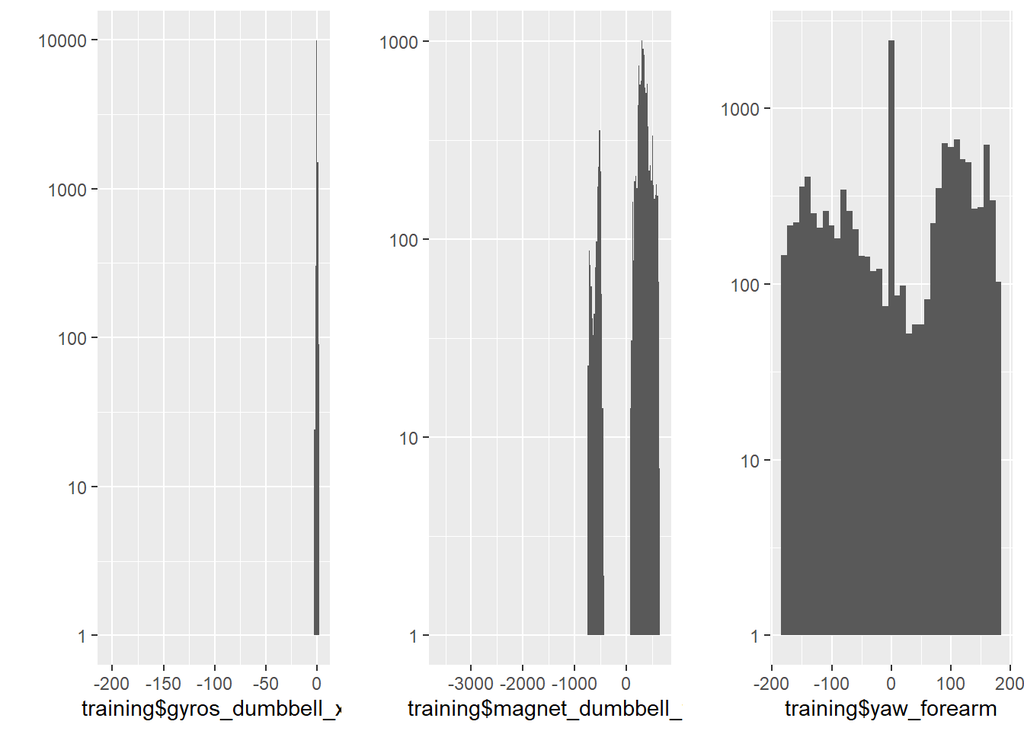

```r
hist1 <- qplot(training$gyros_dumbbell_x, geom="histogram", binwidth = 1) + scale_y_log10()
hist2 <- qplot(training$magnet_dumbbell_y, geom="histogram", binwidth = 20) + scale_y_log10()
hist3 <- qplot(training$yaw_forearm, geom="histogram", binwidth = 10) + scale_y_log10()
grid.arrange(hist1, hist2, hist3, ncol=3)
```

## Variable Selection

Since we have a high number of variables, let’s see if some of them are highly correlated.

```r
M <- abs(cor(training[,-53]))
diag(M) <- 0
which(M>0.9,arr.ind = TRUE)
```

```
##                  row col
## total_accel_belt   4   1
## accel_belt_y       9   1
## accel_belt_z      10   1
## accel_belt_x       8   2
## roll_belt          1   4
## accel_belt_y       9   4
## accel_belt_z      10   4
## pitch_belt         2   8
## roll_belt          1   9
## total_accel_belt   4   9
## accel_belt_z      10   9
## roll_belt          1  10
## total_accel_belt   4  10
## accel_belt_y       9  10
## gyros_arm_y       19  18
## gyros_arm_x       18  19
## gyros_dumbbell_z  33  31
## gyros_forearm_z   46  31
## gyros_dumbbell_x  31  33
## gyros_forearm_z   46  33
## gyros_dumbbell_x  31  46
## gyros_dumbbell_z  33  46
```

Many variables are highly correlated, but it is not surprising due to the way the sensors are positioned on the body. Since it is difficult to determine which ones are the most important, we decide to use all the variables for our model.

## Model Selection

Since we have a large number of highly correlated variables that have non normal distribution, we decided to use a random forest to create our predictive model as it can handle these challenges very well. We then used this model to predict the values in our testing set. The accuracy of our model on the testing set is then displayed.

```r
modFit <- train(classe ~ ., data = training, method = "rf")
pred <- predict(modFit, testing)
confusionMatrix(pred, testing$classe)
```

```
## Confusion Matrix and Statistics
##
##           Reference
## Prediction    A    B    C    D    E
##          A 2232   13    0    0    0
##          B    0 1501   10    0    0
##          C    0    4 1358   19    3
##          D    0    0    0 1264    2
##          E    0    0    0    3 1437
##
## Overall Statistics
##
##                Accuracy : 0.9931
##                  95% CI : (0.991, 0.9948)
##     No Information Rate : 0.2845
##     P-Value [Acc > NIR] : < 2.2e-16
##
##                   Kappa : 0.9913
##
##  Mcnemar's Test P-Value : NA
##
## Statistics by Class:
##
##                      Class: A Class: B Class: C Class: D Class: E
## Sensitivity            1.0000   0.9888   0.9927   0.9829   0.9965
## Specificity            0.9977   0.9984   0.9960   0.9997   0.9995
## Pos Pred Value         0.9942   0.9934   0.9812   0.9984   0.9979
## Neg Pred Value         1.0000   0.9973   0.9985   0.9967   0.9992
## Prevalence             0.2845   0.1935   0.1744   0.1639   0.1838
## Detection Rate         0.2845   0.1913   0.1731   0.1611   0.1832
## Detection Prevalence   0.2861   0.1926   0.1764   0.1614   0.1835
## Balanced Accuracy      0.9988   0.9936   0.9943   0.9913   0.9980
```

Considering the accuracy confidence interval, our out of sample error is still less than 1% on the testing set.

## Cross Validation

```r
modFit
```

```
## Random Forest
##
## 11776 samples
##    52 predictor
##     5 classes: 'A', 'B', 'C', 'D', 'E'
##
## No pre-processing
## Resampling: Bootstrapped (25 reps)
## Summary of sample sizes: 11776, 11776, 11776, 11776, 11776, 11776, ...
## Resampling results across tuning parameters:
##
##   mtry  Accuracy   Kappa
##    2    0.9863021  0.9826767
##   27    0.9859093  0.9821810
##   52    0.9778408  0.9719781
##
## Accuracy was used to select the optimal model using the largest value.
## The final value used for the model was mtry = 2.
```

For a random forest prediction model, the cross validation is done intrinsically. As we can see above, there was 25 resampling repetitions as part of the model creation process.